# (Pretty) big data wrangling with DuckDB and Polars

With examples in R and Python

[Grant McDermott](https://grantmcdermott.com/duckdb-polars)

gmcd@amazon.com

Principal Economist, Amazon

December 15, 2025

## Preliminaries

### Agenda and expectations

These slides are mostly intended to serve as a road map.

- Most of what I’ll (we’ll) be doing is live coding and working through examples.
- I strongly encourage you try these examples on you own machines. Laptops are perfectly fine.

**Note:** All of the materials are available on my website:

- **https://grantmcdermott.com/duckdb-polars**

## Preliminaries

### Requirements

**Important:** If you’d like to follow along, please make sure that you have completed the [requirements](https://grantmcdermott.com/duckdb-polars/requirements.html) listed on the website.

- Install the required R and/or Python libraries.
- Download some NYC taxi data.

The data download step can take 15-20 minutes, depending on your internet connection.

## Problem statement

### Why this workshop?

It’s a trope, but “big data” is everywhere. This is true whether you work in tech (like I do now), or in academic research (like I used to).

OTOH many of datasets that I find myself working with aren’t at the scale of truly *huge* data that might warrant a Spark cluster.

- We’re talking anywhere between 100 MB to 50 GB. (Max a few billion rows; often in the millions or less.)
- Can I do my work without the pain of going through Spark?

Another factor is working in polyglot teams. It would be great to repurpose similar syntax and libraries across languages…

## Taster

### DuckDB example

```r
library(duckdb)
library(arrow)
library(dplyr)

nyc = open_dataset(here::here("nyc-taxi"))
prettyNum(nrow(nyc), ",")
```

```
[1] "178,544,324"
```

```r
tic = Sys.time()

nyc_summ = nyc |>
  to_duckdb() |>
  summarise(
    mean_tip = mean(tip_amount),
    .by = passenger_count
  ) |>
  collect()

(toc = Sys.time() - tic)
```

```
Time difference of 0.912349 secs
```

## Taster

### DuckDB example (cont.)

We just read a ~180 million row dataset (from disk!) and did a group-by aggregation on it.

In < 1 second.

On a laptop.

🤯

## Simple benchmark: Computation time only

### DuckDB and Polars are already plenty fast…

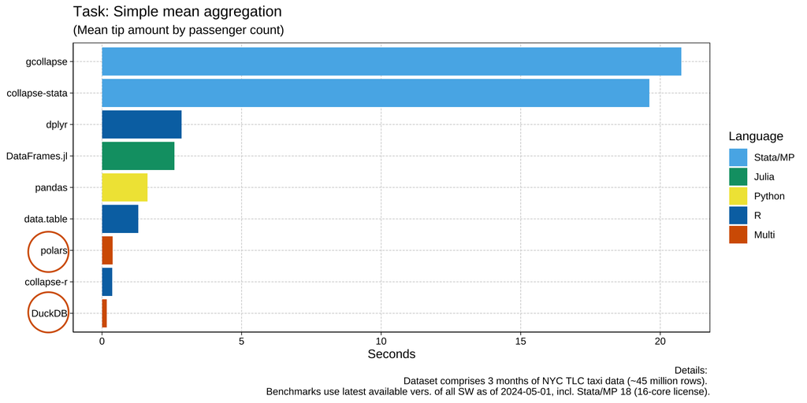

## Simple benchmark: Computation time + data I/O

### … but are even more impressive once we account for data import times

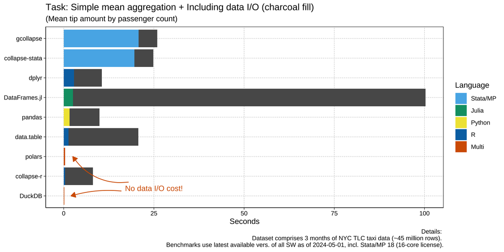

## Wait. How??

### Better disk storage 🤝 Better memory representation

Two coinciding (r)evolutions enable faster, smarter computation:

#### 1. Better on-disk storage

- E.g. Hive-partitioned [Parquet](https://parquet.apache.org/) files.
- Columnar storage format allows better compression (much smaller footprint) and efficient random access to selected rows or columns (don’t have to read the whole dataset *a la* CSVs).

#### 2. Better in-memory representation

- Standardisation around the [Apache Arrow](https://arrow.apache.org/) format + columnar representation. (Allows zero copy, fewer cache misses, etc.)
- [OLAP](https://en.wikipedia.org/wiki/Online_analytical_processing) + [materialisation](https://en.wikipedia.org/wiki/Materialized_view). (Rather than “eagerly” executing each query step, we can be “lazy” and optimise queries before executing them.)

## Query optimization

### Key concepts

Three key optimizations work together:

- **Lazy Materialization:** *When* computation happens
- **Predicate Pushdown:** *Where* filtering happens
- **Projection Pushdown:** *Which* columns are read

## Lazy Materialization

### When computation happens

- Build query plan first, execute later
- Only compute when results are needed (`.collect()`, `.show()`)
- Enables global optimization across entire pipeline

**Example:** `SELECT` operations are bumped to the top of an (optimzed) query to avoid unecessary work

## Predicate Pushdown

### Which rows are read

- Push `WHERE` conditions to the storage layer
- Filter at file/partition level before reading into memory
- Dramatically reduces I/O by skipping irrelevant data

**Example:** `WHERE month = 3` → Only scan March parquet files

## Projection Pushdown

### Which columns are read

- Only read columns actually needed for the query
- Skip unnecessary columns at the storage layer
- Reduces memory usage and I/O bandwidth

**Example:** `SELECT tip_amount` → Only read tip column, skip other 29 columns

## Scaling up

### Even moar benchmarks

**Question:** Do these benchmarks hold and scale more generally? **Answer:** Yes. See [*Database-like ops benchmark*](https://duckdblabs.github.io/db-benchmark/).

Moreover—and I think this is key—these kinds of benchmarks normally exclude the data I/O component… and the associated benefits of not having to hold the whole dataset in RAM.

- There are some fantastically fast in-memory data wrangling libraries out there. (My personal faves: data.table and collapse.) But “in-memory” means that you always have to keep the full dataset in, well, memory. And this can be expensive.
- Libraries like DuckDB and Polars sidestep this problem, effectively supercharging your computer’s data wrangling powers.

## DuckDB

[figure not shown]

- Embedded C++ analytical database (no server needed)
- Multiple language frontends (R, Python, Julia, etc.)
- SQL interface with “friendly” extensions
- Excellent for out-of-memory operations

## Polars

[figure not shown]

- Embedded Rust-based DataFrame library
- Python/R bindings (multiple language support)
- DataFrame interface with lazy evaluation
- Built on Apache Arrow memory format

## Examples

### Live coding sessions

Let’s head back to the website to work through some notebooks.

#### DuckDB

- DuckDB SQL
- DuckDB + dplyr (R)
- DuckDB + Ibis (Python)

#### Polars

- Polars from R and Python

## What didn’t we cover?

### Other cool features

- **S3 I/O**
  - DuckDB & Polars can both read/write directly from/to S3. You just need to provision your AWS credentials. [Ex. [1](https://drive-render.corp.amazon.com/view/gmcd@/codebook/devdesk.html#sec-rs3), [2](https://cboettig.github.io/duckdbfs/), [3](https://medium.com/@louis_10840/how-to-process-data-stored-in-amazon-s3-using-polars-2305bf064c52)]
  - Note: I prefer/recommend the workflow we practiced today—first download to local disk via `aws cli`—to avoid network + I/O latency.
- **Geospatial**
  - IMO the next iteration of geospatial computation will be built on top of the tools we’ve seen today (and related libs).
  - DuckDB provides an excellent [spatial extension](https://github.com/duckdblabs/duckdb_spatial) (works with [dplyr](https://cboettig.github.io/duckdbfs/)). See also the [GeoParquet](https://geoparquet.org/), [GeoArrow](https://geoarrow.org/), & [GeoPolars](https://geopolars.org/latest/) initiatives.

## What didn’t we cover?

### Other cool features (cont.)

- **Streaming**
  - [Streaming](https://pola-rs.github.io/polars-book/user-guide/concepts/streaming/) is the feature that enables working with bigger-than-RAM data.
  - Very easy to use and/or adjust our workflow to these cases…
  - DuckDB: Simply specify a disk-backed database when you first fire up your connection from Python or R, e.g.

  ```r
  con = dbConnect(duckdb(), dbdir = "nyc.dbb")
  ```

  - Polars: Simply specify streaming when collecting, e.g.

  ```python
  some_query.collect(streaming=True)
  ```

## What didn’t we cover?

### Other cool features (cont.)

- **Modeling**
  - The modeling part *used* to be less tightly integrated with DuckDB/Polars workflows. But that’s changing rapidly, e.g.: [**dbreg**](https://github.com/grantmcdermott/dbreg), [**duckreg**](https://github.com/py-econometrics/duckreg), and [**duckdb-mlpack**](https://github.com/eddelbuettel/duckdb-mlpack).
  - FWIW being able to quickly I/O parts of large datasets makes it very easy to iteratively run analyses on subsets of your data. E.g., I often pair with [**fixest**](https://lrberge.github.io/fixest/) for exceptional in-memory performance.
  - You can also run bespoke models via UDFs and/or predictions on database backends. [Ex. [1](https://duckdb.org/2023/07/07/python-udf.html), [2](https://posit-conf-2023.github.io/arrow/materials/4_data_manipulation_2.html#/user-defined-functions-aka-udfs), [3](https://tidypredict.tidymodels.org/)]

## Resources

### Learning more

#### DuckDB

- [DuckDB homepage](https://duckdb.org/). Includes a very informative [blog](https://duckdb.org/news/) and standalone documentation for the client APIs ([Python](https://duckdb.org/docs/archive/0.8.1/api/python/overview), [R](https://duckdb.org/docs/api/r.html), and many others).
- Also check out [Harlequin](https://harlequin.sh/) for a cool, shell-based DuckDB IDE.

#### Polars

- [Polars GitHub Repo](https://github.com/pola-rs/polars). Contains links to the standalone documentation for the client APIS ([Python](https://pola-rs.github.io/polars/py-polars/html/reference/index.html), [R](https://rpolars.github.io/index.html), etc.)
- Side-by-side code comparisons (versus pandas, dplyr, etc.) are available in [*Modern Polars (in Python)*](https://kevinheavey.github.io/modern-polars/) and [*Codebook for Polars in R*](https://ddotta.github.io/cookbook-rpolars/).